# Chapter 6 Lab 5 - Archetypal Analysis (AA)

# Goal

In this lab, we will show you how to use `Archetypal Analysis (AA)` to obtain archetypes from the data.

We will use the AA implementation from the “archetypes” package. See url: https://cran.r-project.org/web/packages/archetypes/archetypes.pdf for more information on the package.

## Preparation

Load the following packages (install if you need to). This is similar to the previous labs, except we are now loading and will be using archetypes package.

```r
options(repos = c(CRAN = "http://cran.rstudio.com"))
install.packages("archetypes", dependencies = TRUE)
library(archetypes) # for archetypal analysis
library(caret) # for preprocessing the data
```

# Step 1: Load the data set

Similar to previous labs, load data and convert to appropriate data type.

```r
# data
Dota_Data <- read.csv("DoTalicious_cleaned1000players.csv", fileEncoding="UTF-8-BOM")
summary(Dota_Data)
```

```
##     PlayerID       GamesPlayed         GamesWon         GamesLeft
##  Min.   :   0.0   Min.   :   0.00   Min.   :   0.00   Min.   : 0.000
##  1st Qu.: 242.8   1st Qu.:   3.00   1st Qu.:   1.00   1st Qu.: 0.000
##  Median : 499.5   Median :  15.00   Median :   7.00   Median : 0.000
##  Mean   : 497.7   Mean   :  92.24   Mean   :  50.31   Mean   : 1.649
##  3rd Qu.: 750.2   3rd Qu.:  90.00   3rd Qu.:  47.25   3rd Qu.: 2.000
##  Max.   :1000.0   Max.   :3156.00   Max.   :1764.00   Max.   :40.000
##     Ditches            Points        SkillLevel            Kills
##  Min.   : 0.0000   Min.   : 626.8   Length:868         Min.   :    0.0
##  1st Qu.: 0.0000   1st Qu.: 962.1   Class :character   1st Qu.:   11.0
##  Median : 0.0000   Median : 996.7   Mode  :character   Median :   74.0
##  Mean   : 0.7108   Mean   :1014.8                      Mean   :  608.0
##  3rd Qu.: 1.0000   3rd Qu.:1046.7                      3rd Qu.:  512.8
##  Max.   :18.0000   Max.   :2010.2                      Max.   :23742.0
##   KillsPerMin         Deaths           Assists         CreepsKilled
##  Min.   :0.0000   Min.   :    0.0   Min.   :    0.0   Min.   :     0.0
##  1st Qu.:0.0900   1st Qu.:   17.0   1st Qu.:   18.0   1st Qu.:   159.5
##  Median :0.1300   Median :   92.5   Median :  124.0   Median :   979.0
##  Mean   :0.1316   Mean   :  544.5   Mean   :  950.7   Mean   :  7628.0
##  3rd Qu.:0.1700   3rd Qu.:  554.0   3rd Qu.:  863.5   3rd Qu.:  6723.0
##  Max.   :0.4200   Max.   :16988.0   Max.   :34390.0   Max.   :372360.0
##   CreepsDenied     NeutralsKilled    TowersDestroyed   RaxsDestroyed
##  Min.   :    0.0   Min.   :    0.0   Min.   :   0.00   Min.   :   0.00
##  1st Qu.:   12.0   1st Qu.:   16.0   1st Qu.:   1.00   1st Qu.:   0.00
##  Median :   76.0   Median :  145.5   Median :   7.00   Median :   3.00
##  Mean   :  676.9   Mean   : 1258.3   Mean   :  70.71   Mean   :  29.71
##  3rd Qu.:  540.8   3rd Qu.: 1126.8   3rd Qu.:  61.50   3rd Qu.:  26.00
##  Max.   :43910.0   Max.   :42900.0   Max.   :2601.00   Max.   :1141.00
##   TotalTime
##  Length:868
##  Class :character
##  Mode  :character
##
##
##
```

```r
# convert TotalTime
Dota_Data$TotalTime <- as.numeric(Dota_Data$TotalTime)
# exclude the row with SillLevel = SkillLevelNull
Dota_Data$SkillLevel <- as.factor(Dota_Data$SkillLevel)
Dota_Data <- Dota_Data[!(Dota_Data$SkillLevel == " SkillLevelNull"),]

# use factor in place of as.factor to remove " SkillLevelNull" from the list of factors
Dota_Data$SkillLevel <- factor(Dota_Data$SkillLevel)

# exclude PlayerID
Dota_Data <- Dota_Data[-1]
```

Similar to previous labs, assign the `SkillLevel` to `row.names` for visualization later.

```r
# make the names of levels descriptive and assign them to row.names
levels(Dota_Data$SkillLevel) <- c("N", "B", "I", "A")
row.names(Dota_Data) <- make.names(Dota_Data[,"SkillLevel"], unique = TRUE)
```

Similar to previous labs, exclude the `SkillLevel` column, since it is not numeric. Archetypcal clustering algorithm only works with numeric variables.

```r
attribs_except_skill <- -which(names(Dota_Data) %in% c("SkillLevel"))
DotaData_NoSkill <- Dota_Data[, attribs_except_skill]
```

Finally, similar to previous labs, scale the data.

```r
preProcValues <- preProcess(x = DotaData_NoSkill,method = c("center", "scale"))
DotaData_NoSkill <- predict(preProcValues, DotaData_NoSkill)
```

Check if there are any missing values (NA here means Not Available). If it returns *False*, we’re good to go. We will leave out the rows with NAs, if they exist.

```r
anyNA(DotaData_NoSkill)
```

```
## [1] TRUE
```

```r
DotaData_NoSkill = na.omit(DotaData_NoSkill)
```

# Step 2: Apply the Archetypal Analysis

We use the `stepArchetypes` function from the `archetypes` library. This function runs AA multiple times with different values of `K`, the number of archetypes.

```r
set.seed(2063)

# run archetypal analysis multiple times with different K, in this line we are considering values of 1-10 for K.
ArchetypesForDota <- stepArchetypes(data = DotaData_NoSkill, k = 1:10, verbose = FALSE, nrep = 4)
```

```
## Warning in method(..., k = k[i]): k=8: zs > maxKappa

## Warning in method(..., k = k[i]): k=8: zs > maxKappa

## Warning in method(..., k = k[i]): k=8: zs > maxKappa

## Warning in method(..., k = k[i]): k=8: zs > maxKappa
```

```
## Warning in method(..., k = k[i]): k=9: zs > maxKappa

## Warning in method(..., k = k[i]): k=9: zs > maxKappa

## Warning in method(..., k = k[i]): k=9: zs > maxKappa

## Warning in method(..., k = k[i]): k=9: zs > maxKappa
```

```
## Warning in method(..., k = k[i]): k=10: zs > maxKappa

## Warning in method(..., k = k[i]): k=10: zs > maxKappa

## Warning in method(..., k = k[i]): k=10: zs > maxKappa

## Warning in method(..., k = k[i]): k=10: zs > maxKappa
```

We tried 10 different values of `K`, from 1 to 10, and repeated the `AA` algorithm 4 times per `K`. Since solving for archetypes is stochastic, it can converge to suboptimal solutions, thus repeating it multiple times of `K` helps ensure that we do not get stuck in local optima.

If you see some warnings, those indicate that the matrices were singular, which can be caused by some unfavorable random initializations, and can be ignored.

Next, the `screeplot` function shows the plot of RSS (Residual Sum of Squares) scores w.r.t different numbers of archetypes. The lower the RSS score is, the better the model is.

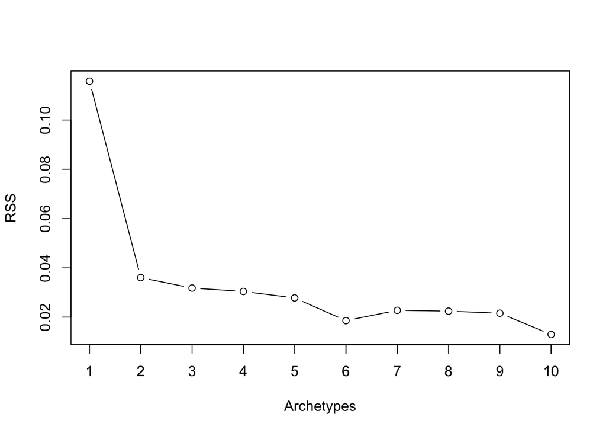

```r
screeplot(ArchetypesForDota)
```

To obtain the resultant archetypes with respect to different `K` values, we use the `bestModel` function. For example, the following shows information related to the model at `K=10`.

```r
num_archs <- 10
BestArchetypeModelForDota <- bestModel(ArchetypesForDota[[num_archs]])
BestArchetypeModelForDota
```

```
## Archetypes object
##
## method(data = ..1, k = k[i])
##
## Convergence after 33 iterations
## with RSS = 0.01294024.
```

And this shows that the Archetypes obtained with `K=10`.

```r
BestArchetypeModelForDota$archetypes
```

```
##       GamesPlayed   GamesWon    GamesLeft    Ditches      Points      Kills
##  [1,]  -0.3324730 -0.4063905  4.158784752  2.3722667 -0.31730443 -0.3834540
##  [2,]  14.6063760 14.5050385 11.597880038  0.6993711  3.23814056 15.0890086
##  [3,]  -0.1505756 -0.2060495  2.329846753 -0.3717860 -2.61567178 -0.1738794
##  [4,]  -0.4348153 -0.4221789 -0.508352305 -0.3901774  0.30889866 -0.4012403
##  [5,]   7.4113476  6.9195556  2.386279583  3.8418610  0.95662255  4.9059082
##  [6,]  -0.4407514 -0.4261154 -0.305381448 -0.3935541 -0.50582129 -0.3936888
##  [7,]   1.0030233  1.1813651  1.815405301  0.9238761  7.27260512  1.5428029
##  [8,]   3.2467946  3.2212626  1.702088398  7.2454182  0.79985181  2.8884888
##  [9,]   0.2595877  0.3152718 -0.327245299 -0.3939598 -0.04343914  0.2922883
## [10,]  -0.3978722 -0.4138491  0.006302718 -0.3373095 -1.93522312 -0.3899157
##       KillsPerMin      Deaths    Assists CreepsKilled CreepsDenied
##  [1,] -0.31935167 -0.41781941 -0.3968047   -0.3672579   -0.3201985
##  [2,]  2.94604412 13.38332553 14.6910658   18.0521585   20.8725862
##  [3,]  0.01369677 -0.13160782 -0.1881802   -0.1392921   -0.1154787
```

[output cut: 18 more lines]

Let’s take a look at the data by raw and their alpha coefficients given Archetype. This will help us establish which Archetype each data point belongs to.

```r
BestArchetypeModelForDota$alphas
```

```
##                [,1]         [,2]         [,3]        [,4]         [,5]
##   [1,] 6.645805e-02 1.952306e-02 0.0000000000 0.003156361 7.831207e-03
##   [2,] 0.000000e+00 1.349523e-03 0.0000000000 0.496444584 2.353777e-02
##   [3,] 0.000000e+00 0.000000e+00 0.0000000000 0.648937632 0.000000e+00
##   [4,] 1.284070e-01 1.269832e-02 0.0000000000 0.133304509 0.000000e+00
##   [5,] 0.000000e+00 0.000000e+00 0.0000000000 0.267243720 0.000000e+00
##   [6,] 0.000000e+00 0.000000e+00 0.0000000000 0.427574975 0.000000e+00
##   [7,] 0.000000e+00 0.000000e+00 0.0000000000 0.373901186 1.226307e-03
##   [8,] 0.000000e+00 0.000000e+00 0.0000000000 0.534538760 0.000000e+00
##   [9,] 0.000000e+00 0.000000e+00 0.0000000000 0.573776077 0.000000e+00
##  [10,] 6.828210e-03 0.000000e+00 0.3994836172 0.374211124 9.530448e-02
##  [11,] 0.000000e+00 0.000000e+00 0.0000000000 0.497186976 0.000000e+00
##  [12,] 0.000000e+00 4.875985e-03 0.0000000000 0.191105753 0.000000e+00
##  [13,] 4.365220e-01 2.540265e-02 0.2090684599 0.000000000 0.000000e+00
##  [14,] 0.000000e+00 0.000000e+00 0.0000000000 0.456051097 0.000000e+00
```

[output cut: 1719 more lines]

# Step 3: Visualization

Archetypes are different from clusters in the traditional sense, and more similar to principle components in PCA.

One way to visualize archetypes is by using `simplexplot`.

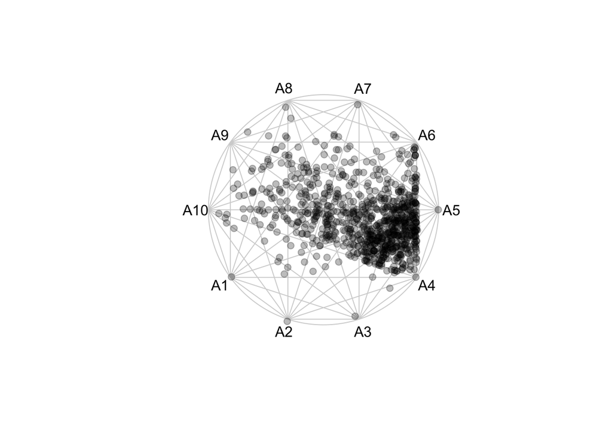

```r
simplexplot(bestModel(ArchetypesForDota[[num_archs]]))
```

In the plot, the archetypes are shown on the perimeter of a simplex, named as `A_1` to `A_K` (K=10 in this case), containing the data points. The distances between each data point to the archetypes represent the “closeness” it is to the archetypes.

Let’s try with a smaller K, such as 6.

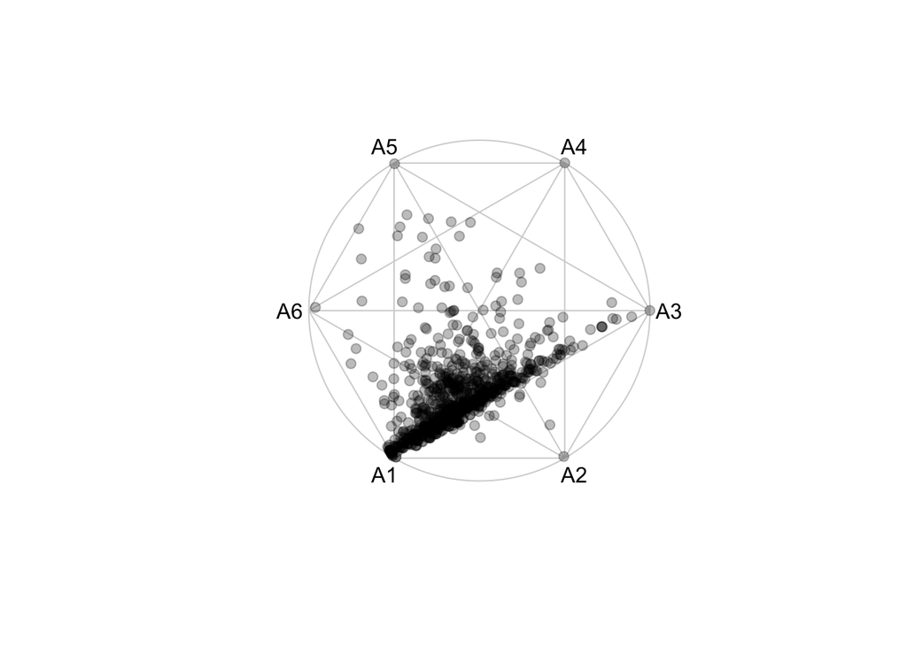

```r
simplexplot(bestModel(ArchetypesForDota[[6]]))
```

# Conclusion

In this lab, we showed you how to use Archetypal analysis to extract archetypes from a data set. This type of algorithm is very different from others, so you can compare the results qualitatively to other algorithms and see what results in better qualitative clusters.